# ΔDOC or downstream DOC as the outcome of the structural causal model?

A balanced comparison of the two parameterizations

Author

Leonardo Capitani

Published

September 9, 2026

**TipThe two research questions**

**Q1 — Direction.** *Do beaver-engineered streams act as sources or sinks of DOC, and does that depend on the season?* Answered by **Q1_model**: a paired-contrast measurement-error model on the four measured concentrations, with no drivers in it.

**Q2 — Drivers.** *Which abiotic and biotic drivers set the direction and size of the local DOC change?* Answered by a structural causal model (SCM) fitted in two parameterizations, **Q2_delta** and **Q2_downstream**, which estimate the paths dams → water residence time → primary producers → DOC, solar radiation → producers → DOC, litter → DOC, and upstream DOC → producers.

Q3 (magnitude: the inherited contrast $S$, the relative response $R_s$ and the seasonal gain $G$) uses a fourth model on the concentrations and is not discussed here.

**ImportantThe three models, their outcome variables, and the aim of this document**

| Model | Question | Outcome variable | Drivers in the model |
| --- | --- | --- | --- |
| **Q1_model** | Q1 | $\Delta\text{DOC} = \text{DOC}_{down} - \text{DOC}_{up}$ | none: the concentrations alone |
| **Q2_delta** (file `delta_SCM_me`) | Q2 | $\Delta\text{DOC}$ | all |
| **Q2_downstream** (file `downstream_DOC_me`) | Q2 | $\text{DOC}_{down}$ | all |

**The aim of this document is to compare Q2_delta and Q2_downstream** — the same SCM written with the local change or with the downstream concentration as the response — and to ask whether either of them can also answer Q1 in place of Q1_model (Section 8).

**TipThe two parameterizations of the Q2 model**

|  | **Q2_delta** | **Q2_downstream** |
| --- | --- | --- |
| Outcome | $\Delta\text{DOC} = \text{DOC}_{down} - \text{DOC}_{up}$ | $\text{DOC}_{down}$ |
| Instrument error on the outcome | 0.283 mg L$^{-1}$ — the errors of both readings, $\sqrt{0.2^2 + 0.2^2}$ | 0.2 mg L$^{-1}$ — one reading |
| Upstream DOC | latent true value (its reading carries the 0.2 mg L$^{-1}$ error), standardized, as a predictor of ΔDOC *and* subtracted inside ΔDOC | latent true value (0.2 mg L$^{-1}$ error), in mg L$^{-1}$, as a predictor with a freely estimated **inheritance slope** |
| Links upstream DOC → phytoplankton, → macrophytes | yes | yes |
| Mediators, priors, stream random effect, Student-*t* likelihood, sampler | identical | identical |
| ΔDOC | is the outcome | is derived afterwards: predicted downstream DOC minus upstream DOC, per posterior draw |

Both are fitted to the same data (360 samplings; producers at 16 streams) with the same DAG (Figure 1). Both account for the measurement error of upstream DOC (Section 4).

**TipThe questions addressed**

1. Why does Q2_downstream have **downstream DOC**, not **ΔDOC**, as its outcome? What does the link upstream DOC → ΔDOC in Q2_delta represent, as against upstream DOC → downstream DOC in Q2_downstream? (Section 2)
2. Does the choice **change the inference**? (Section 3, Section 5)
3. Where is the evidence that the model predicts downstream DOC well (predicted vs observed), and **how is ΔDOC estimated a posteriori** from a model that never sees it? (Section 6, Section 7)
4. If ΔDOC is derived from the prediction, does the **specification of the SCM** bias it? Would it be safer to model ΔDOC directly from the data? (Section 9)
5. Should both models account for the **measurement error of upstream DOC**? (Section 4)
6. **What do we gain** with Q2_downstream over Q2_delta? (Section 10)
7. If beavers can raise or lower downstream DOC *depending on how much comes in*, the structure needs the links upstream DOC → primary producers as well as the direct link: what do the two DAGs look like and what do they give? (Section 1, Section 11)
8. Our interest is beaver-engineering’s effect on **ΔDOC**, not on downstream DOC; and if Q2_downstream is on downstream DOC, should the figures not show it? (Section 12)
9. Can the Q2 models **answer Q1 as well**, in place of Q1_model? (Section 8)

**ImportantShort answer**

# 1. The two DAGs

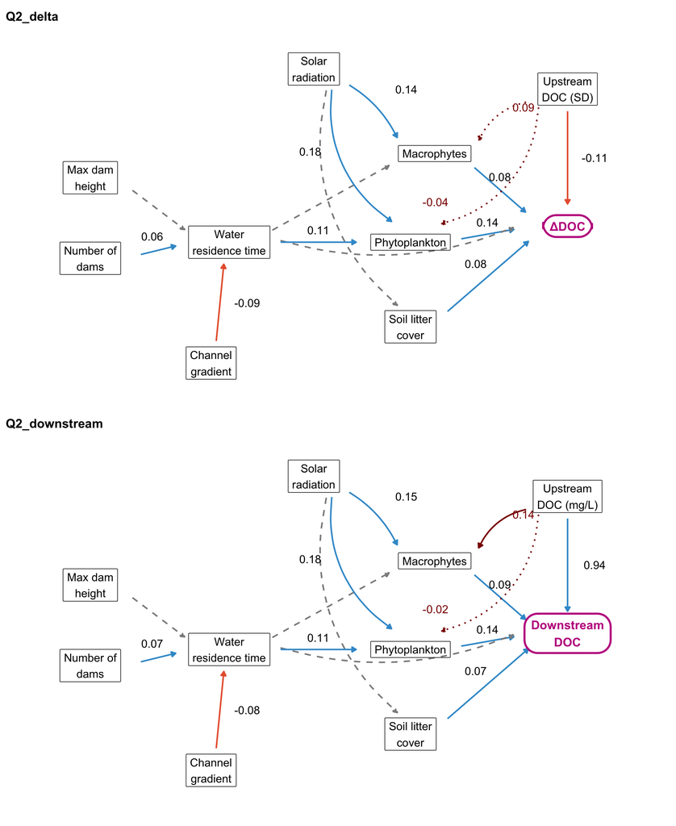

```r
fig_me <- draw_dag(tD, "ΔDOC", "deltaDOC", "DOC_input_z", "Upstream\nDOC (SD)", "Q2_delta") /
          draw_dag(tO, "Downstream\nDOC", "DOCout", "DOC_input", "Upstream\nDOC (mg/L)", "Q2_downstream")
ggsave(here("results", "figures", "plan", "fig_refit_dags.png"), fig_me, width = 9, height = 11, dpi = 300, bg = "white"); fig_me
```

Max R-hat: 1.012 (Q2_delta), 1.021 (Q2_downstream).

# 2. What the link from upstream DOC represents in each model

**Question:** What does the link upstream DOC → ΔDOC represent, as against upstream DOC → downstream DOC — and why keep upstream DOC as a separate term at all?

The two arrows from upstream DOC in Figure 1 are one quantity seen from two sides. Write $\beta_{inh}$ for the coefficient of upstream DOC on downstream DOC (Q2_downstream) and $\beta_1$ for its coefficient on ΔDOC (Q2_delta, in mg per mg). Because $\Delta\text{DOC} = \text{DOC}_{down} - \text{DOC}_{up}$,

$$\beta_1 = \beta_{inh} - 1 .
\tag{1}$$

**ImportantWhat each arrow says**

- $\beta_{inh}$ = 0.94 mg per mg is the **fraction of the inflow passed on**, and its distance from one is the removal that scales with the inflow.
- $\beta_1$ = -0.05 mg per mg is the **net change per mg entering**, which mixes that removal with the $-1$ the subtraction contributes by construction.
- Upstream DOC is kept as its own term because it is the one variable beaver engineering cannot cause, so it fixes the inherited baseline that $S$, $R_s$ and $G$ are defined on.

# 3. One model, two parameterizations

**Question:** Does the choice of outcome change the inference?

Q2_delta and Q2_downstream are the same regression written around two different outcomes: ΔDOC is nothing but downstream DOC minus upstream DOC, so subtracting upstream DOC from one equation gives back the other, term for term. What follows makes that subtraction explicit.

**Q2_delta**, with mediators $M_k$ (macrophytes, phytoplankton, litter cover, water residence time) and a stream random intercept $u$:

$$\begin{aligned}
\Delta\text{DOC}_i &= \text{DOC}_{down,i} - \text{DOC}_{up,i} \\
\Delta\text{DOC}_i &\sim \text{Student-}t\!\left(\nu,\; \mu^{\Delta}_i,\; \sigma\right) \\
\mu^{\Delta}_i &= \alpha + \beta_1\,\text{DOC}_{up,i} + \sum_k \beta_k M_{k,i} + u_{site(i)}
\end{aligned}
\tag{2}$$

**Q2_downstream**:

$$\begin{aligned}
\text{DOC}_{down,i} &\sim \text{Student-}t\!\left(\nu,\; \mu_i,\; \sigma\right) \\
\mu_i &= \alpha' + \beta_{inh}\,\text{DOC}_{up,i} + \sum_k \beta'_k M_{k,i} + u'_{site(i)}
\end{aligned}
\tag{3}$$

Subtracting $\text{DOC}_{up,i}$ from both sides of Equation 3 gives

$$\text{DOC}_{down,i} - \text{DOC}_{up,i} = \alpha' + (\beta_{inh} - 1)\,\text{DOC}_{up,i} + \sum_k \beta'_k M_{k,i} + u'_{site(i)} + \varepsilon_i ,
\tag{4}$$

which is Equation 2 with $\beta_1 = \beta_{inh} - 1$ (Equation 1), $\beta_k = \beta'_k$ and the same $\nu$, $\sigma$, $u$. One likelihood, two coordinate systems. The fitted models confirm it:

Table 1: The same SCM fitted as Q2_delta (ΔDOC outcome) and Q2_downstream (downstream-DOC outcome), both with the upstream measurement error and the producer links. Posterior mean [95% credible interval]. The inheritance slope implied by Q2_delta is 1 + β₁/SD(upstream DOC).

| Parameter | Q2_delta: outcome ΔDOC | Q2_downstream: outcome downstream DOC |
| --- | --- | --- |
| Inheritance slope (mg per mg) | 0.949 [0.912, 0.985] | 0.940 [0.894, 0.985] |
| Upstream DOC → ΔDOC (mg per mg) | -0.051 [-0.088, -0.015] | -0.060 [-0.106, -0.015] |
| Macrophytes → outcome | 0.083 [-0.004, 0.177] | 0.093 [-0.002, 0.191] |
| Phytoplankton → outcome | 0.144 [0.034, 0.256] | 0.144 [0.032, 0.258] |
| Soil litter cover → outcome | 0.076 [-0.031, 0.183] | 0.074 [-0.024, 0.182] |
| Water residence time → outcome | 0.028 [-0.052, 0.115] | 0.024 [-0.064, 0.109] |
| Upstream DOC → macrophytes (per SD / per mg L⁻¹) | 0.090 [-0.094, 0.273] | 0.143 [-0.008, 0.282] |
| Upstream DOC → phytoplankton (per SD / per mg L⁻¹) | -0.035 [-0.202, 0.141] | -0.025 [-0.147, 0.097] |
| Between-stream SD | 0.047 [0.002, 0.137] | 0.049 [0.002, 0.141] |
| Residual scale σ | 0.304 [0.251, 0.360] | 0.306 [0.253, 0.363] |
| Degrees of freedom ν | 2.074 [2.002, 2.280] | 2.072 [2.002, 2.265] |
| Average ΔDOC (Q2_delta intercept; Q2_downstream evaluated at mean upstream DOC) | 0.005 [-0.114, 0.119] | -0.004 [-0.129, 0.117] |

**ImportantKey message of Table 1**

- Mediator effects, producer links, stream SD, residual scale and tail parameter are the same in the two models.
- The two readings of the inheritance differ only at the second decimal, from the error correlation of Section 4.
- **Implication.** The choice of outcome sets which number is reported first, not what is inferred.

# 4. Propagation of the measurement error in the two models

**Question:** Should both models account for the 0.2 mg L$^{-1}$ instrument error of upstream DOC, and do they propagate it in the same way?

Both do now: in each model, the upstream reading is a noisy measurement of a latent true concentration (error 0.2 mg L$^{-1}$, or 0.098 on the standardized scale), and the latent value — not the reading — enters the outcome equation and the two producer equations. But the two models cannot propagate it in the same way, and the reason is the definition of ΔDOC:

- **Q2_delta.** The outcome is built from two readings, so it carries their combined error, $\sqrt{0.2^2 + 0.2^2} = 0.283$ mg L$^{-1}$. The upstream reading is *also* the predictor, with its own 0.2 error. The same physical error therefore appears twice — once inside the outcome’s error, once on the predictor — and the two are negatively correlated (a reading that is too high makes ΔDOC too low and the predictor too high). brms models the two errors as independent; the correlation is ignored.
- **Q2_downstream.** The outcome is one reading with its own error (0.2); the upstream reading is the predictor with its own error (0.2). Each error appears exactly once, and independence is correct.

**ImportantConclusion**

# 5. A practical comparison

**Question:** In practice, what does each model give directly, and how well does each predict?

What each model gives, and how well it predicts (PSIS-LOO on the observed samplings; max R-hat 1.012 and 1.021).

|  | Q2_delta | Q2_downstream |
| --- | --- | --- |
| Number reported directly for upstream DOC | net change per unit inflow: −0.05 mg per mg | fraction inherited: 0.94 mg per mg |
| Average ΔDOC | the intercept, directly | one subtraction: intercept + (β_inh − 1) × mean upstream DOC |
| Mediator effects on the local change | directly | directly (identical numbers) |
| Effect of the inflow on the producers (new links) | directly | directly (identical signs) |
| ΔDOC of each sampling | the fitted value | one subtraction: predicted downstream DOC − upstream DOC |
| Out-of-sample accuracy for its own outcome (LOO R², RMSE, 90% coverage) | ΔDOC: R² -0.03, RMSE 2.75 (mean-only 2.72), 84% | downstream DOC: R² 0.45, RMSE 2.75 (mean-only 3.73), 85% |
| Out-of-sample accuracy for ΔDOC | R² -0.03, RMSE 2.75 | R² -0.03, RMSE 2.75 (derived) |
| Measurement error | outcome 0.283 + upstream 0.2, correlated (ignored) | outcome 0.2 + upstream 0.2, independent (correct) |
| What it states about upstream DOC | a net change per unit inflow | an inherited state, the baseline of S, R_s and G |

**Neither model predicts ΔDOC out of sample.** Q2_delta, which has ΔDOC as its outcome, does no better than its mean, and so does the derived ΔDOC of Q2_downstream: a property of the system, not of the parameterization.

# 6. Predictive accuracy of the two models

**Question:** How well does each model predict its own outcome, and ΔDOC, out of sample — predicted against observed?

Pareto-smoothed importance-sampling leave-one-out cross-validation (PSIS-LOO): each observed value is predicted as if it had been left out of the fit. Q2_delta predicts ΔDOC; Q2_downstream predicts downstream DOC, and ΔDOC by subtraction.

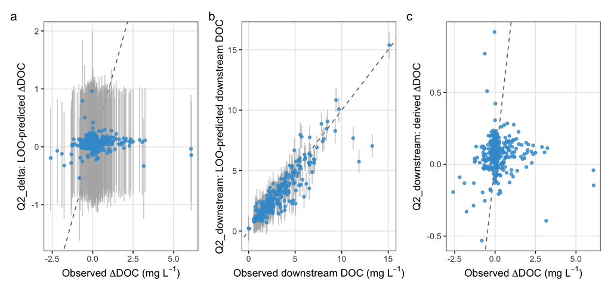

Figure 2: **Predicted vs observed, both Q2 models (leave-one-out).** (a) Q2_delta: LOO-predicted ΔDOC against the observed ΔDOC of each sampling. (b) Q2_downstream: LOO-predicted downstream DOC against the observed concentration. (c) Q2_downstream: ΔDOC derived from the LOO prediction against the observed ΔDOC. Segments: 90% LOO predictive interval where available; dashed: 1:1. Samplings with |ΔDOC| above 10 mg L⁻¹ or downstream DOC above 20 mg L⁻¹ are outside the plotted range; the statistics of Table 2 use every sampling.

```r
if (have_pred) {
  # lim: samplings whose observed or predicted value exceeds it are dropped from the
  # display only (10 mg/L for dDOC, 20 mg/L for downstream DOC); the LOO statistics use all data.
  pp <- function(x, y, lo = NULL, hi = NULL, xl, yl, lim) {
    d <- tibble(x, y, lo = if (is.null(lo)) NA_real_ else lo, hi = if (is.null(hi)) NA_real_ else hi)
    d <- d[abs(d$x) <= lim & abs(d$y) <= lim, ]
    p <- ggplot(d, aes(x, y)) + geom_abline(slope = 1, intercept = 0, linetype = "dashed", colour = "grey45")
    if (!is.null(lo)) p <- p + geom_linerange(aes(ymin = lo, ymax = hi), colour = "grey70", alpha = .6)
    p + geom_point(size = 1.2, colour = "#3B9AD1", alpha = .8) + labs(x = xl, y = yl) + theme_bw(base_size = 11) + theme(panel.grid.minor = element_blank()) }
  ib <- match(P$both, P$obsO)
  pa <- pp(P$d_obs, P$D$mu_loo, P$D$q_loo[1, ], P$D$q_loo[2, ], expression("Observed "*Delta*"DOC (mg "*L^-1*")"), expression("Q2_delta: LOO-predicted "*Delta*"DOC"), lim = 10)
  pb <- pp(P$y_out, P$O$mu_loo, P$O$q_loo[1, ], P$O$q_loo[2, ], expression("Observed downstream DOC (mg "*L^-1*")"), "Q2_downstream: LOO-predicted downstream DOC", lim = 20)
  pc <- pp(P$d_obs, P$O$mu_loo[ib] - P$up_both, NULL, NULL, expression("Observed "*Delta*"DOC (mg "*L^-1*")"), expression("Q2_downstream: derived "*Delta*"DOC"), lim = 10)
  pa + pb + pc + plot_annotation(tag_levels = "a")
}
```

Table 2: Out-of-sample accuracy of the two models (PSIS-LOO on the observed samplings).

| Model | Quantity predicted | LOO R² | LOO RMSE (mg L⁻¹) | RMSE of predicting the mean | 90% interval coverage |
| --- | --- | --- | --- | --- | --- |
| Q2_delta | ΔDOC (its outcome) | -0.03 | 2.75 | 2.72 | 84% |
| Q2_downstream | downstream DOC (its outcome) | 0.45 | 2.75 | 3.73 | 85% |
| Q2_downstream | ΔDOC (derived) | -0.03 | 2.75 | 2.72 | — |

**ImportantKey message of Figure 2**

- Both models predict ΔDOC out of sample no better than its mean (Q2_delta R² -0.03; Q2_downstream derived R² -0.03), because the local change is small and stream-specific (Q1).
- Q2_downstream predicts downstream DOC with R² 0.45, RMSE 2.75 against 3.73 for the mean, and calibrated 90% intervals (85% coverage), almost all of it inheritance.
- **Implication.** Predictive accuracy does not separate the two parameterizations: the same information is in both, and what can and cannot be predicted is a property of the system.

# 7. The a-posteriori derivation of ΔDOC

**Question:** How is ΔDOC estimated a posteriori from a model that never sees it, and is it the same ΔDOC that Q2_delta fits directly?

ΔDOC is computed after fitting, once per posterior draw $d$ and sampling $i$, from two numbers the draw already contains:

$$\begin{aligned}
\Delta\text{DOC}^{(d)}_i &= \mu^{(d)}_i - \text{DOC}_{up,i} \\
&= \alpha'^{(d)} + \left(\beta_{inh}^{(d)} - 1\right)\text{DOC}_{up,i} + \sum_k \beta'^{(d)}_k M_{k,i} + u'^{(d)}_{site(i)}
\end{aligned}
\tag{5}$$

(with the latent upstream value of the draw). The seasonal average is the same operation averaged over the samplings of a season:

$$\overline{\Delta\text{DOC}}^{(d)}_{s} = \frac{1}{n_s}\sum_{i \in s} \Delta\text{DOC}^{(d)}_i
\tag{6}$$

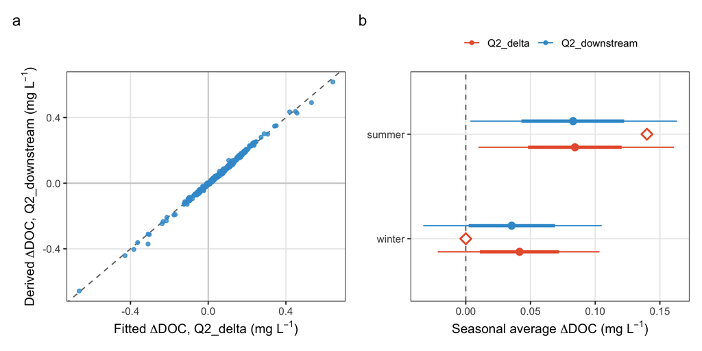

Figure 3: **ΔDOC from the two models.** (a) The ΔDOC of every sampling: derived from Q2_downstream (Equation 5) against fitted directly by Q2_delta; posterior medians; dashed: 1:1. (b) The seasonal average ΔDOC from both models (Equation 6); point: median, bars: 66% and 95% credible intervals; open diamonds: Q1_model on the concentrations alone (+0.14 mg L⁻¹ summer, 0.00 winter).

```r
if (have_pred) {
  pa <- ggplot(tibble(x = P$D$dd_med, y = P$O$dd_med), aes(x, y)) +
    geom_abline(slope = 1, intercept = 0, linetype = "dashed", colour = "grey45") +
    geom_hline(yintercept = 0, colour = "grey80") + geom_vline(xintercept = 0, colour = "grey80") +
    geom_point(size = 1.4, colour = "#3B9AD1", alpha = .8) +
    labs(x = expression("Fitted "*Delta*"DOC, Q2_delta (mg "*L^-1*")"), y = expression("Derived "*Delta*"DOC, Q2_downstream (mg "*L^-1*")")) +
    theme_bw(base_size = 12) + theme(panel.grid.minor = element_blank())
  av <- bind_rows(as_tibble(P$D$avg_season) |> mutate(model = "Q2_delta"), as_tibble(P$O$avg_season) |> mutate(model = "Q2_downstream")) |>
    pivot_longer(c(summer, winter), names_to = "season", values_to = "v") |> mutate(season = factor(season, levels = c("winter", "summer")))
  q1 <- tibble(season = factor(c("winter", "summer"), levels = c("winter", "summer")), v = c(0.00, 0.14))
  pb <- ggplot(av, aes(x = v, y = season, colour = model)) + geom_vline(xintercept = 0, linetype = "dashed", colour = "grey45") +
    stat_pointinterval(.width = c(.66, .95), point_interval = "median_qi", position = position_dodge(width = .5)) +
    geom_point(data = q1, aes(x = v, y = season), inherit.aes = FALSE, shape = 23, size = 3, fill = "white", colour = "#E8603C", stroke = 1.2) +
    scale_colour_manual(values = c(Q2_delta = "#E8603C", Q2_downstream = "#3B9AD1"), name = NULL) +
    labs(x = expression("Seasonal average "*Delta*"DOC (mg "*L^-1*")"), y = NULL) +
    theme_bw(base_size = 12) + theme(panel.grid.minor = element_blank(), legend.position = "top")
  pa + pb + plot_annotation(tag_levels = "a")
}
```

**ImportantKey message of Figure 3**

- The ΔDOC of every sampling is the same in the two models (correlation 0.998, median absolute difference 0.006 mg L⁻¹): the subtraction recovers what Q2_delta fits.
- Seasonal averages: Q2_delta 0.084 [0.010, 0.161] (summer) and 0.042 [-0.022, 0.103] (winter); Q2_downstream 0.083 [0.003, 0.163] and 0.035 [-0.033, 0.105]; Q1_model, from the concentrations alone, +0.14 [0.05, 0.22] and 0.00 [−0.06, 0.07].
- **Implication.** Nothing about ΔDOC is lost by not making it the outcome; the derived quantity is the fitted quantity.

# 8. Answering Q1 with the Q2 models

**Question:** Q1 is answered by Q1_model, which uses the concentrations alone; can the two Q2 models answer it as well, so that one model serves both questions?

Q1 asks two things: the average ΔDOC per season, and the posterior predictive shares of sink, negligible and source responses for a single sampling (ROPE ±0.5 mg L$^{-1}$). Both come from either Q2 model: the seasonal average from Equation 6, and the shares from the posterior predictive distribution of ΔDOC for a new sampling — directly in Q2_delta, and as (predicted downstream DOC − upstream DOC) in Q2_downstream. Q2_delta states ΔDOC as its outcome, so it is the closer substitute for Q1_model; Figure 4 is its graph.

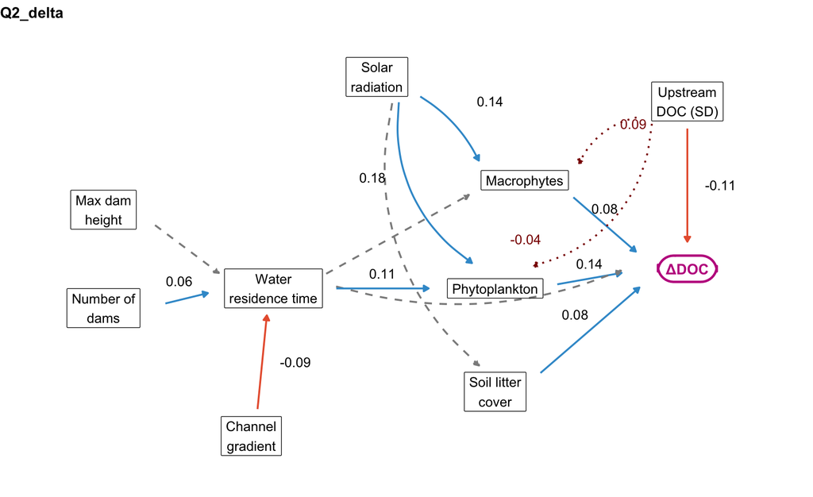

Figure 4: **Q2_delta, the model used here to answer Q1.** Its outcome is the local change itself, so the sink / negligible / source shares of Q1 come from its posterior predictive distribution; Q1_model, by contrast, holds none of these drivers. The coefficient on upstream DOC is per SD. Dark red: the links upstream DOC → macrophytes and → phytoplankton. Solid: posterior probability of the sign above 0.90; dashed/dotted: no-evidence.

```r
draw_dag(tD, "ΔDOC", "deltaDOC", "DOC_input_z", "Upstream\nDOC (SD)", "Q2_delta")
```

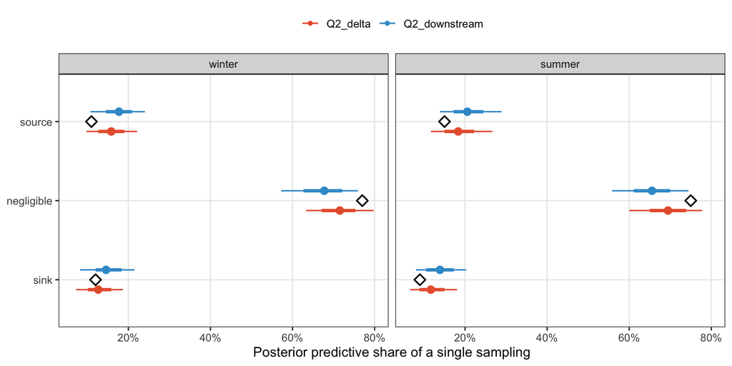

Figure 5: **Q1 answered from the two Q2 models.** Posterior predictive shares of a single sampling showing a sink (ΔDOC < −0.5 mg L⁻¹), a negligible (within ±0.5) or a source (> 0.5) response, by season and model; point: median, bars: 66% and 95% credible intervals. Open diamonds: the shares given by Q1_model on the concentrations alone (winter 12 / 77 / 11%, summer 9 / 75 / 15%).

```r
if (have_pred) ggplot(sh, aes(x = p, y = response, colour = model)) +
  stat_pointinterval(.width = c(.66, .95), point_interval = "median_qi", position = position_dodge(width = .5)) +
  geom_point(data = ref, aes(x = p, y = response), inherit.aes = FALSE, shape = 23, size = 3, fill = "white", colour = "black", stroke = 1) +
  facet_wrap(~ season) + scale_colour_manual(values = c(Q2_delta = "#E8603C", Q2_downstream = "#3B9AD1"), name = NULL) +
  scale_x_continuous(labels = label_percent(accuracy = 1)) +
  labs(x = "Posterior predictive share of a single sampling", y = NULL) + theme_bw(base_size = 12) + theme(panel.grid.minor = element_blank(), legend.position = "top")
```

**ImportantKey message of Figure 5**

- The Q2 models reproduce the Q1 answer: negligible responses in 68% (winter) and 66% (summer) of single samplings under Q2_downstream (Q2_delta 72% and 69%), against 77% and 75% from Q1_model, with sources slightly more likely than sinks in summer in every model.
- The seasonal averages are those of Figure 3 b: the same ordering as Q1_model, with overlapping intervals, from a model that also carries the drivers.
- **Implication (the option).** Q1 can be answered from Q2_delta instead of Q1_model, at the price that its numbers then depend on the SCM specification, with the mediators imputed at 342 of 360 samplings.

# 9. Dependence of the derived ΔDOC on the model specification

**Question:** If ΔDOC is derived from the model’s prediction, does adding or removing a variable from the SCM change it — and bias the inference built on it? Would it be safer to model ΔDOC directly from the data?

The concern is right in general, and it is answered in two parts.

**No conclusion is drawn from the SCM’s ΔDOC.** Two different quantities are called ΔDOC:

|  | Where it comes from | Depends on the SCM’s variables? | Used for |
| --- | --- | --- | --- |
| **ΔDOC from the data** | Q1_model on the raw concentrations (Q1) and the four-concentration model behind $S$, $R_s$, $B$, $G$ (Q3) — no mediators, no drivers | **no** | every conclusion on direction, magnitude and seasonal gain |
| **ΔDOC from the SCM** | $\mu_i - \text{DOC}_{up,i}$, the SCM’s *expected* local modification given the drivers (Equation 5) | **yes**, as any fitted value does | interpreting Q2: which pathways contribute (the decomposition), and the checks in this document |

So ΔDOC is already modelled directly from the data wherever a conclusion about ΔDOC is drawn. The SCM’s ΔDOC is a fitted value, and fitted values depend on the specification in both parameterizations equally, because they are the same likelihood (Equation 4; Figure 3 a). How far they move when the structure changes is measured by the structural-sensitivity analysis in `analysis_plan.qmd`, section 9 (alternative DAGs, unmeasured confounding, priors).

# 10. The gain: the meaning of the coefficient on upstream DOC

**Question:** What do we actually gain with downstream DOC as the outcome instead of ΔDOC?

The gain is the meaning of one number (Section 2): -0.11 per SD on ΔDOC becomes 0.94 mg per mg inherited, whose distance from one *is* the removal that scales with the inflow. With it come the inherited state as a stated quantity, one appearance of each measurement error (Section 4), and an inflow-through-producers effect of a variable that is not also inside the outcome (Section 11). Not gained: fit, mediator estimates, predictive accuracy (Section 5).

# 11. The inflow through the producers: direct, indirect and total effects

**Question:** With the links upstream DOC → producers in the DAG, does the baseline modulate the beaver modification through the producers, and by how much?

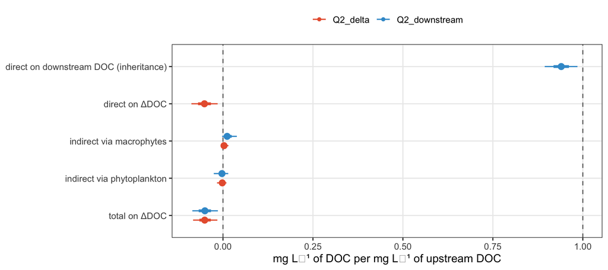

Figure 6: **How the inflow reaches the local change, in mg per mg of upstream DOC, in both models.** Posterior distributions of the direct effect of upstream DOC (on downstream DOC in Q2_downstream — the inheritance; on ΔDOC in Q2_delta), the two indirect effects through the producers, and the total effect on ΔDOC; point: median, bars: 66% and 95% credible intervals; dashed: 0 and 1.

```r
if (have_pred) {
  lv <- c("total on ΔDOC", "indirect via phytoplankton", "indirect via macrophytes", "direct on ΔDOC", "direct on downstream DOC (inheritance)")
  ggplot(eff |> mutate(effect = factor(effect, levels = lv)), aes(x = v, y = effect, colour = model)) +
    geom_vline(xintercept = c(0, 1), linetype = "dashed", colour = "grey45") +
    stat_pointinterval(.width = c(.66, .95), point_interval = "median_qi", position = position_dodge(width = .5)) +
    scale_colour_manual(values = c(Q2_delta = "#E8603C", Q2_downstream = "#3B9AD1"), name = NULL) +
    labs(x = "mg L⁻¹ of DOC per mg L⁻¹ of upstream DOC", y = NULL) + theme_bw(base_size = 12) + theme(panel.grid.minor = element_blank(), legend.position = "top")
}
```

**ImportantKey message of Figure 6**

- **The links are supported for macrophytes, not for phytoplankton.** Upstream DOC → macrophytes 0.143 [-0.008, 0.282] per mg L⁻¹ (P > 0 = 0.97); upstream DOC → phytoplankton -0.025 [-0.147, 0.097] (P > 0 = 0.34); the same signs in Q2_delta.
- **The indirect route is an order of magnitude below the direct one.** Indirect effect of the inflow on ΔDOC through the producers: 0.010 [-0.018, 0.042] mg per mg (Q2_downstream), 0.001 [-0.016, 0.017] (Q2_delta); total effect of the inflow on ΔDOC: -0.050 [-0.085, -0.014] and -0.051 [-0.083, -0.016].
- **Implication.** The baseline does modulate the beaver modification, through macrophytes only, and the modulation is small against the direct shortfall: the more DOC enters, the lower the delta (about −0.05 mg per mg), and the producers do not reverse that. The two models agree on every number; only Q2_downstream names the inheritance.

# 12. The target quantity and the figures

**Question:** Our interest is the effect of beaver-engineering on ΔDOC, not on downstream DOC, which depends almost entirely on upstream DOC; we want to see how the delta changes with the input. And if the model is now on downstream DOC, should the figures not show downstream DOC?

The target is the local modification, and the parameterization does not change it:

- **The estimand is the local modification.** Every effect in Q2_downstream — the mediator coefficients, the derived ΔDOC, the pathway decomposition — is an effect on $\mu_i - \text{DOC}_{up,i}$, identical draw for draw to the fitted ΔDOC of Q2_delta (Figure 3 a). Downstream DOC is the *response* of the likelihood, not the object of inference.
- **“How the delta changes with the input” is one coefficient, estimated in both models.** It is $\beta_1 = \beta_{inh} - 1$ = -0.060 [-0.106, -0.015] mg per mg (Q2_downstream) and -0.052 [-0.088, -0.015] (Q2_delta): the delta falls as the input rises — the beaver system dampens a rich inflow — plus the producer route of Section 11. Figure 7 shows it on the data.
- **The figures.** The graph of the Q2 model (Figure 1, bottom) has downstream DOC as its outcome node because that is what it predicts, and the predicted-versus-observed check (Figure 2 b) is on downstream DOC for the same reason. Everything reported as a result — the direction shares (Figure 5), the seasonal averages (Figure 3 b), $R_s$ and $G$, the pathway decomposition — is on ΔDOC or on quantities built from it.

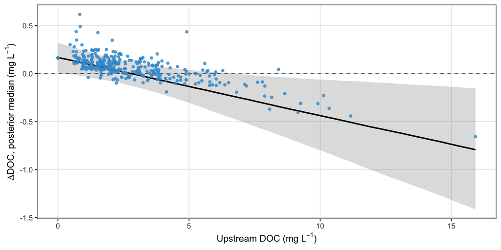

Figure 7: **The local modification as a function of the input.** ΔDOC of every sampling (posterior median; derived from Q2_downstream) against the observed upstream DOC; black line and band: the expected ΔDOC at the mean of the mediators, α + (β_inh − 1)·DOC_up, posterior median and 95% credible interval; dashed: zero. The slope of the line is β₁ in mg per mg.

```r
if (have_pred) {
  dm <- P$O$dd_med; up <- P$up_both
  grid <- seq(min(up), max(up), length.out = 80)
  line <- sapply(grid, function(u) cO[, "b_DOCout_Intercept"] + (cO[, "bsp_DOCout_miDOC_input"] - 1) * u)
  ln <- tibble(up = grid, med = apply(line, 2, median), lo = apply(line, 2, quantile, .025), hi = apply(line, 2, quantile, .975))
  ggplot(tibble(up, dm), aes(up, dm)) + geom_hline(yintercept = 0, linetype = "dashed", colour = "grey45") +
    geom_ribbon(data = ln, aes(x = up, ymin = lo, ymax = hi), inherit.aes = FALSE, fill = "black", alpha = .15) +
    geom_line(data = ln, aes(up, med), colour = "black", linewidth = 0.9) +
    geom_point(size = 1.3, colour = "#3B9AD1", alpha = .8) +
    labs(x = expression("Upstream DOC (mg "*L^-1*")"), y = expression(Delta*"DOC, posterior median (mg "*L^-1*")")) +
    theme_bw(base_size = 12) + theme(panel.grid.minor = element_blank())
}
```

**ImportantKey message of Figure 7**

- The local change shifts by -0.060 [-0.106, -0.015] mg L⁻¹ per additional mg L⁻¹ of DOC entering the stream, so a rich inflow is dampened and a poor one enriched.
- The zero crossing sits at 2.8 mg L⁻¹ of upstream DOC: below it the expected ΔDOC is positive, above it negative.
- **Implication.** The delta is read against the input, and the input is a term of the model, which is why upstream DOC is kept explicit rather than folded into the outcome.

# 13. Reproducibility

```
Models: Q2_delta = results/models_fit/delta_SCM_me.rds, Q2_downstream = results/models_fit/downstream_DOC_me.rds (notebook/R/me_refits.R)
 Predictions and LOO: notebook/R/me_predictions.R -> results/me_predictions.rds
```

```
[1] "R version 4.6.1 (2026-06-24)"
```